# Билет 1

```python
import numpy as np
import matplotlib.pyplot as plt
import matplotlib
```

### Задача 1

#### Доказательство корректности определения суммы и произведения двух вещественных чисел.

#### $ \forall a, b \in \mathbb{R} \ \exists! a \cdot b $

#### $ \forall a, b \in \mathbb{R}, a > 0, b > 0 $ число $ c \in \mathbb{R} $ называется их произведением, если $ \forall \alpha_1, \beta_1, \alpha_2, \beta_2 \in \mathbb{Q} $, т.ч. $ 0 < \alpha_1 \leqslant a \leqslant \alpha_2, 0 < \beta_1 \leqslant b \leqslant \beta_2: \alpha_1 \beta_1 \leqslant c \leqslant \alpha_2 \beta_2 $

#### Существование $ c $

Докажем случай $ a > 0, b > 0 $. Рассмотрим $ A = \{\alpha_1 \beta_1 \ | \ \alpha_1, \beta_1 \in \mathbb{Q}, 0 < \alpha_1 \leqslant a, 0 < \beta_1 \leqslant b \} $

Т.к. $ \alpha_1\beta_2 \leqslant ab \leqslant \alpha_2\beta_2, \exists \ sup \ A = c, c \leqslant \alpha_2\beta_2 $. Т.к. $ c = sup \ A, c \geqslant \alpha_1\beta_1 \Rightarrow c = ab $

#### Единственность $ c $

Пусть $ c_1 = ab, c_2 = ab. \varepsilon > 0, \varepsilon \in \mathbb{Q}. M = max\{[a], [b]\} + 1 \ \ (m > a, M > b) $.

По Л2 $ \exists \alpha_1, \beta_1, \alpha_2, \beta_2 \in \mathbb{Q} $, т.ч. $ 0 < \alpha_1 \leqslant a \leqslant \alpha_2 \leqslant M, 0 < \beta_1 \leqslant b \leqslant \beta_2 \leqslant M $, причём $ \alpha_1 - \alpha_2 < \frac{\varepsilon}{2M}, \beta_1 - \beta_2 < \frac{\varepsilon}{2M} $

Тогда $ \alpha_1\beta_1 \leqslant c_1 \leqslant \alpha_2\beta_2, \alpha_1\beta_1 \leqslant c_2 \leqslant \alpha_2\beta_2 $

$ \alpha_2\beta_2 - \alpha_1\beta_1 = \alpha_2(\beta_2 - \beta_1) + \beta_1(\alpha_2 - \alpha_1) \leqslant M ((\beta_2 - \beta_1) + (\alpha_2 - \alpha_1)) \leqslant 2\varepsilon \Rightarrow c_1 = c_2 $

#### $ \forall a, b \in \mathbb{R} \ \exists! c = a + b $

Число $ c \in \mathbb{R} $ называется суммой $ a, b \in \mathbb{R} $, если $ \forall \alpha_1, \alpha_2, \beta_1, \beta_2 \in \mathbb{Q}: \alpha_1 \leqslant a \leqslant \alpha_2 \ \beta_1 \leqslant b \leqslant \beta_2 \ \alpha_1 + \beta_1 \leqslant c \leqslant \alpha_2 + \beta_2 $

#### Существование $ c $

$ A = \{ \alpha_1 + \beta_1 | \alpha_1, \beta_1 \in \mathbb{Q}, \alpha_1 \leqslant a, \beta_1 \leqslant b \}, A \neq \emptyset. \exists sup \ A \ (\alpha_1 \leqslant \alpha_2, \beta_1 \leqslant \beta_2) $  
$ sup \ A = c \geqslant \alpha_1 + \beta_1 \ \forall \alpha_1, \beta_1 \in \mathbb{Q}: \alpha_1 \leqslant a, \beta_1 \leqslant b (c = sup \ A) $  
Но $ c \leqslant \alpha_2 + \beta_2 \ \forall \alpha_2, \beta_2 \in \mathbb{Q}: \alpha_2 \geqslant a, \beta_2 \geqslant b \Rightarrow \alpha_1 + \beta_1 \leqslant c \leqslant \alpha_2 + \beta_2 $ и $ c = a + b $ по определению

#### Единственность $ c $

Пусть $ c_1 = a + b, c_2 = a + b \Rightarrow \exists \alpha_1, \alpha_2, \beta_1, \beta_2 \in \mathbb{Q}: \ \alpha_1 \leqslant a \leqslant \alpha_2, \ \beta_1 \leqslant b \leqslant \beta_2, $  
$\alpha_2 - \alpha_1 < \frac{\varepsilon}{2}, \beta_2 - \beta_1 < \frac{\varepsilon}{2} $  
$ \delta_1 = \alpha_1 + \beta_1, \delta_2 = \alpha_2 + \beta_2 \Rightarrow \delta_1 \leqslant c_1 \leqslant \delta_2, \delta_1 \leqslant c_2 \leqslant \delta_2, \delta_2 - \delta_1 < \varepsilon \Rightarrow c_1 = c_2 $ (по лемме 3)

### Задача 2

#### Определение, свойства и график функции $ y = sin x $

$ X = \mathbb{R} $, $ Y = [-1, 1] $

Функция нечётная, периодическая ($ T = 2\pi $).

Возрастает на $ [-\frac{\pi}{2} + 2 \pi k, \frac{\pi}{2} + 2 \pi k] $, убывает на $ [\frac{\pi}{2} + 2 \pi k, \frac{3 \pi}{2} + 2 \pi k], k \in \mathbb{Z} $

Функция непрерывна на $ \mathbb{R} $

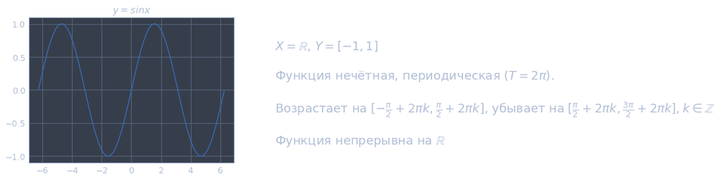

```python
x = np.linspace(- 2 * np.pi, 2 * np.pi, 200)
y = np.sin(x)

matplotlib.rcParams.update({'font.size': 18})

fig, axs = plt.subplots(1, 2, figsize=(12, 4))
axs[0].plot(x, y)
axs[0].set_title('$ y=sin x $')

axs[1].axis('off')
axs[1].text(0, 0.02, r"""
$ X = \mathbb{R} $, $ Y = [-1, 1] $

Функция нечётная, периодическая ($ T = 2\pi $).

Возрастает на $ [-\frac{\pi}{2} + 2 \pi k, \frac{\pi}{2} + 2 \pi k] $, убывает на $ [\frac{\pi}{2} + 2 \pi k, \frac{3 \pi}{2} + 2 \pi k], k \in \mathbb{Z} $

Функция непрерывна на $ \mathbb{R} $
""")
plt.show()
```

### Задача 3

#### Определение ограниченного (сверху, снизу) числового множества.

Множество $ A $ называется ограниченным (сверху, снизу), если $ \exists \space m, M \in \mathbb{R} $ ($ m, M $), т.ч. $ \forall \space a \in A, \space m \leqslant a \leqslant M (a \leqslant M, m \leqslant a) $

### Задача 4

#### Определение по Гейне: $ \exists \space lim_{x \to -\infty} f(x) = a $

Число $ b \in \mathbb{R} $ является пределом функции f, если $ \forall \{x_n\} $ аргументов, т.ч. $ x_n \underset{n \to \infty}{\to} -\infty: f(x_n) \to b $

### Задача 5

#### Дать определение: $ \phi(x) \sim \psi(x), x \to a $

Если $ \exists \lim\limits_{x \to a} \frac{\phi(x)}{\psi(x)} = 1 $, то $ \phi(x) \sim \psi(x), x \to a $